# Homework 2

**This homework is due on Feb. 1, 2021 at 11:00pm. Please submit as a pdf file on Canvas.**

In this homework you will be working with the `iris` dataset built into R. This data set contains measurements of flowers (sepal length, sepal width, petal length, petal width) for three different *Iris* species (*I. setosa*, *I. versicolor*, *I. virginica*).

```r
head(iris)
```

```
##   Sepal.Length Sepal.Width Petal.Length Petal.Width Species
## 1          5.1         3.5          1.4         0.2  setosa
## 2          4.9         3.0          1.4         0.2  setosa
## 3          4.7         3.2          1.3         0.2  setosa
## 4          4.6         3.1          1.5         0.2  setosa
## 5          5.0         3.6          1.4         0.2  setosa
## 6          5.4         3.9          1.7         0.4  setosa
```

**Problem 1: (6 pts)** Use ggplot to make a histogram of the `Sepal.Length` column. Manually choose appropriate values for `binwidth` and `center`. Explain your choice of values in 2-3 sentences.

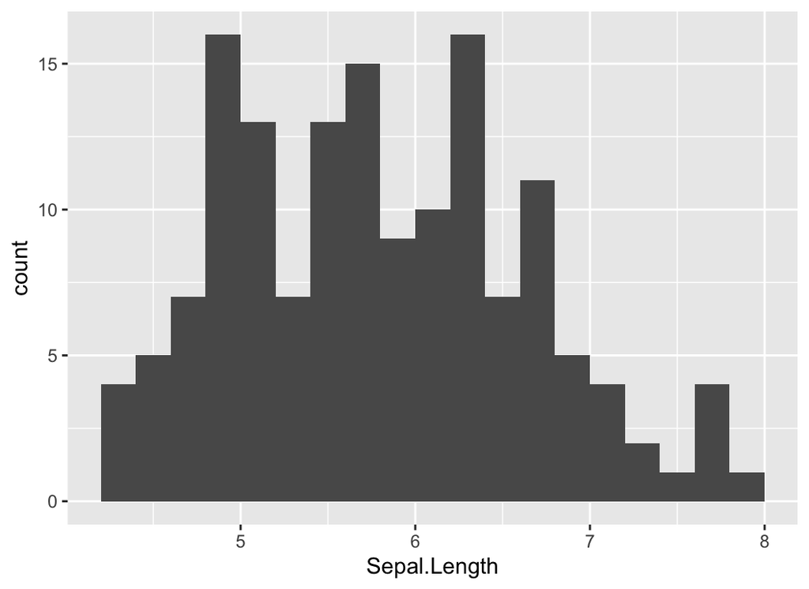

```r
ggplot(iris, aes(Sepal.Length)) +
  geom_histogram(binwidth = 0.2, center = 0.1)
```

Sepal lengths vary from about 4 to about 8, so a binwidth of 0.2 creates 20 bins, enough to see the overall shape of the histogram but not so many that we end up with many empty or near-empty bins. Setting the `center` value to half the `binwidth` value makes sure bins are aligned to round numbers.

**Problem 2: (4 pts)** Modify the plot from Problem 1 to show one panel per species. Hint: Use `facet_wrap()`. See Slide 14 from Class 2.

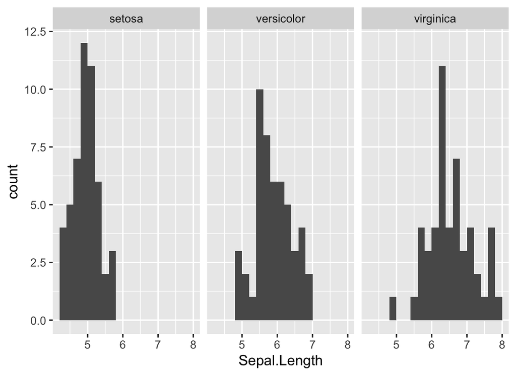

```r
ggplot(iris, aes(Sepal.Length)) +
  geom_histogram(binwidth = 0.2, center = 0.1) +
  facet_wrap(vars(Species))
```